# PCA and Clustering Analysis

## LOF Algorithm Approach 1

The Local Outlier Factor(LOF) algorithm will be utilized from the Library Dbscan to address these outliers. The LOF algorithm works by first calculating the distances (Euclidean by default) for each datapoint from its nearest neighbor. I.e if there are 5 neighbors, (houses in this case), then the algorithm will first calculate the “Reachable Distance” (RD) from each of the neighbors to the observation. This is controlled by the minPts parameter in the DBscan’s implementation of LOF.

- If minPts is set to 5, then the 5 nearest neighbors will be utilized to determine if an observation is an outlier. A higher minPt will search more of the dataset while a lower minPt will do a smaller, more localized search.
- It should also be noted that the number of neighbors is determined by us. As a general guideline, most people recommend 3-5 neighbors, since any more neighbors may result in observations (“houses” in this context) which are a bit further away.

Afterwards, to calculate the “Local Reachable Density” (LRD), the algorithm will compute the following equation:

*Knn = K-nearest neighbors, where k is the number of neighbors specified.

- RD = Reachable Distance for each neighbor which is then summed.
  - i = represents which neighbor is being computed. In the context of this example, there are 5 neighbors, so 5 neighbors would be summed.

This equation will give the LRD for all of the datapoints. Afterwards, the LOF Score is calculated by first computing the ratio of LRD of nearest neighbor to LRD of observation. For instance, if there are 5 neighbors, A,B,C,D,E and we are interested in G, then the formula would be this this:

$$\frac{\text{LRD}(A)}{\text{LRD}(G)} +
\frac{\text{LRD}(B)}{\text{LRD}(G)} +
\frac{\text{LRD}(C)}{\text{LRD}(G)} +
\frac{\text{LRD}(D)}{\text{LRD}(G)} +
\frac{\text{LRD}(E)}{\text{LRD}(G)}$$

Afterwards, this will be divided by the number of neighbors to calculate the average. Thus, the LOF Score essentially takes the average ratio of the LRD and its neighbors. This is shown in the formula down below.

Formula:

$$\frac{\frac{\text{LRD}(A)}{\text{LRD}(G)} +
\frac{\text{LRD}(B)}{\text{LRD}(G)} +
\frac{\text{LRD}(C)}{\text{LRD}(G)} +
\frac{\text{LRD}(D)}{\text{LRD}(G)} +
\frac{\text{LRD}(E)}{\text{LRD}(G)}}{5}$$

Finally, this will be calculated for every observation in the dataset. (In other words, every observation in the dataset will have an LOF Score.)

A point is considered an outlier if (LOF Score) is significantly higher than its neighbors. This is determined by selecting a threshold score. If the LOF Score is higher than the threshold score, then the observation is marked as an outlier.

The threshold is an arbitrary number determined by us, but there are some guidelines. Additionally, there are other alternative like Local Outlier Probability (LOOP) which will be explained in more detail in **LOF Algorithm Approach 2**.

Guidelines for Threshold:

LOF Values Around 1:

- For most data points that are not outliers, the LOF score will be close to 1.
- LOF scores of 1 indicate that the point is in a region of similar density as its neighbors, so it’s not considered an outlier.

LOF Values $>$ 1:

- LOF scores greater than 1 indicate potential outliers. The larger the score, the more likely the point is an outlier.
- Common thresholds for identifying outliers are LOF scores between 1.5 to 2 and higher.

Typical Thresholds:

- Threshold between 1.5 and 2: This range often works well for flagging moderate outliers.

This also means that a lower threshold will result in the LOF algorithm classifying more observations as outliers. (Observation’s LOF Score must be greater than the outlier.) This also means that a higher threshold will result in the LOF algorithm classifying less observations as outliers.

```r
threshold <- 1.5 #Determined by us

# First get all numeric columns to remove outliers

numeric_columns <- sapply(house_prices, is.numeric)

house_clean_numeric <- house_prices[, numeric_columns] # subset train_clean using only numeric cols  (33 cols)


# remove missing value cols

house_clean_numeric <- house_clean_numeric %>% select(-GarageYrBlt) #LOF can't have any missing values, this column was left missing on purpose (32 cols)

# Set up LOF Algorithm
lof_scores <- lof(house_clean_numeric, minPts = 6) #minPts = k nearest neighbors to compare the densities
outliers <- house_prices[lof_scores > threshold, ] # If lof_score > 1.5 - outlier

house_clean_filtered <- house_prices[lof_scores <= threshold, ] # Filter original train_clean to only include non_outliers. If a row has an lof score that is greater than 1.5, it's an outlier. However, this means that if a row has a LOF score that is less than 1.5, it's considered an observation.

# Get the row indices of the filtered dataset
filtered_indices <- rownames(house_clean_filtered)

# Use these indices to filter the original dataset
house_prices_LOF_01 <- house_prices[filtered_indices, ]

# Calculate how many rows have been taken away from the train_clean dataset.
row_reduction <- ((1460 - nrow(house_prices_LOF_01))/1460) * 100

# Round this output to 2
round(row_reduction,2)
```

```
## [1] 5.27
```

I chose relatively conservative values for the algorithm since it’s crucial to keep as many rows as possible. If too many rows are eliminated, then any model will not have enough data to learn any patterns. The row reduction was 5.27% with the dataset decreasing from 1460 rows to 1383 rows.

```r
summary(house_prices)
```

```
##    MSSubClass     MSZoning     LotFrontage        LotArea        Street
##  20     :536   C (all):  10   Min.   : 21.00   Min.   :  1300   Grvl:   6
##  60     :299   FV     :  65   1st Qu.: 60.00   1st Qu.:  7554   Pave:1454
##  50     :144   RH     :  16   Median : 69.00   Median :  9478
##  120    : 87   RL     :1151   Mean   : 69.86   Mean   : 10517
##  30     : 69   RM     : 218   3rd Qu.: 79.00   3rd Qu.: 11602
##  160    : 63                  Max.   :313.00   Max.   :215245
##  (Other):262
##       Alley      LotShape  LandContour  Utilities      LotConfig    LandSlope
##  Grvl    :  50   IR1:484   Bnk:  63    AllPub:1459   Corner : 263   Gtl:1382
##  No Alley:1369   IR2: 41   HLS:  50    NoSeWa:   1   CulDSac:  94   Mod:  65
##  Pave    :  41   IR3: 10   Low:  36                  FR2    :  47   Sev:  13
##                  Reg:925   Lvl:1311                  FR3    :   4
##                                                      Inside :1052
##
##
##   Neighborhood   Condition1     Condition2     BldgType      HouseStyle
##  NAmes  :225   Norm   :1260   Norm   :1445   1Fam  :1220   1Story :726
##  CollgCr:150   Feedr  :  81   Feedr  :   6   2fmCon:  31   2Story :445
##  OldTown:113   Artery :  48   Artery :   2   Duplex:  52   1.5Fin :154
##  Edwards:100   RRAn   :  26   PosN   :   2   Twnhs :  43   SLvl   : 65
##  Somerst: 86   PosN   :  19   RRNn   :   2   TwnhsE: 114   SFoyer : 37
##  Gilbert: 79   RRAe   :  11   PosA   :   1                 1.5Unf : 14
##  (Other):707   (Other):  15   (Other):   2                 (Other): 19
##   OverallQual   OverallCond    YearBuilt     YearRemodAdd    RoofStyle
##  5      :397   5      :821   Min.   :1872   Min.   :1950   Flat   :  13
##  6      :374   6      :252   1st Qu.:1954   1st Qu.:1967   Gable  :1141
##  7      :319   7      :205   Median :1973   Median :1994   Gambrel:  11
##  8      :168   8      : 72   Mean   :1971   Mean   :1985   Hip    : 286
##  4      :116   4      : 57   3rd Qu.:2000   3rd Qu.:2004   Mansard:   7
##  9      : 43   3      : 25   Max.   :2010   Max.   :2010   Shed   :   2
##  (Other): 43   (Other): 28
##     RoofMatl     Exterior1st   Exterior2nd    MasVnrType    MasVnrArea
##  CompShg:1434   VinylSd:515   VinylSd:504   BrkCmn : 15   Min.   :   0.0
##  Tar&Grv:  11   HdBoard:222   MetalSd:214   BrkFace:445   1st Qu.:   0.0
##  WdShngl:   6   MetalSd:220   HdBoard:207   None   :872   Median :   0.0
##  WdShake:   5   Wd Sdng:206   Wd Sdng:197   Stone  :128   Mean   : 103.1
##  ClyTile:   1   Plywood:108   Plywood:142                 3rd Qu.: 164.2
##  Membran:   1   CemntBd: 61   CmentBd: 60                 Max.   :1600.0
##  (Other):   2   (Other):128   (Other):136
```

[output cut: 81 more lines]

```
##  GdPrv   :  59   Gar2           :   2   Min.   :    0.00   6      :253
##  GdWo    :  54   No Misc Feature:1406   1st Qu.:    0.00   7      :234
##  MnPrv   : 157   Othr           :   2   Median :    0.00   5      :204
##  MnWw    :  11   Shed           :  49   Mean   :   43.49   4      :141
##  No Fence:1179   TenC           :   1   3rd Qu.:    0.00   8      :122
##                                         Max.   :15500.00   3      :106
##                                                            (Other):400
##      YrSold        SaleType    SaleCondition    SalePrice      HasGarage
##  Min.   :2006   WD     :1267   Abnorml: 101   Min.   : 34900   No :  81
##  1st Qu.:2007   New    : 122   AdjLand:   4   1st Qu.:129975   Yes:1379
##  Median :2008   COD    :  43   Alloca :  12   Median :163000
##  Mean   :2008   ConLD  :   9   Family :  20   Mean   :180921
##  3rd Qu.:2009   ConLI  :   5   Normal :1198   3rd Qu.:214000
##  Max.   :2010   ConLw  :   5   Partial: 125   Max.   :755000
##                 (Other):   9
```

```r
ncol(house_prices_LOF_01)
```

```
## [1] 81
```

```r
nrow(house_prices_LOF_01)
```

```
## [1] 1383
```

The overall house_prices data set now are 1,383 rows and 81 columns. The original dataset before cleaning had 1,460 rows and 81 columns.

## LOF Algorithm Approach 2

The second approach is to utilize LOOP (Local Outlier Probability) where it utilizes the LOF Scores to calculate the probability of an observation being an outlier.

Afterwards any observations that have a greater than 75% probability of being an outlier will be removed from the dataset.

```r
lof<- sapply(5:10, function(k) LOF(house_clean_numeric,k))
```

This above code calculates 6 LOF Values for each row in the dataset. For instance, for row 1, the chunk will calculate the LOF for 5 neighbors, 6 neighbors, etc. up to 10 neighbors.

```r
#calcuate median lof of different neighborhood sizes.


lof<-apply(lof,1,median)
```

The above code then calculates the median LOF score for each row from the 6 LOF scores previously generated for each row.

```r
loop<- sapply(5:10, function(k) LOOP(house_clean_numeric,k))
loop<-apply(loop,1,median)

# Remove observation with LOOP more than .75
house_prices_LOF_02 <- house_clean_filtered[loop <= 0.75, ]
```

A potential issue however that was present in the last approach with utilizing the LOF Algorithm was that the threshold was a little arbitrarily decided. A potential work around to this issue is to utilize LOOP. LOOP utilizes LOF Scores to calculate the probability of an observation being an outlier. Afterwards, any LOOP values that are greater than .75 would be filtered out from the dataset.

This method is more robust then the LOF Approach #1 where a threshold was somewhat arbitrarily selected based on some guidelines. Additionally, this method calculates the median LOF Score across different number of neighbors which gives a more robust view of an observation’s Local Reachabilty Density and LOF score. (This is because we are taking the median of several LOF Scores as opposed to just one LOF score like in the previous method.)

There is the issue of selecting which probabilty threshold should be selected for determining if something is an outlier. However, the median LOF Scores which are used to calculate the LOOP should provide a better view than just using LOF Scores from a fixed neighbor number. (i.e calculating the LOF Scores from just 6 neighbors for every observation.)

```r
row_reduction_02 <- ((1460 - nrow(house_prices_LOF_02))/1460) * 100

round(row_reduction_02,2)
```

```
## [1] 1.44
```

```r
nrow(house_prices_LOF_02)
```

```
## [1] 1439
```

```r
ncol(house_prices_LOF_02)
```

```
## [1] 81
```

The dataset now has 1,439 rows and 81 columns. This is a 1.44% reduction which means that 98.56% of the data has been conserved.

### Final Thoughts on LOF Approach 1 vs LOF Approach 2

Based on the results, we have decided to go with LOF Approach 2 because it’s a more robust approach that considers the impact of multiple neighbors (5 nearest neighbors to 10 nearest neighbors) by calculating the median. Calculating the median of the different LOF scores helps to show a more consistent picture of an observation’s density point. Furthermore, when combined with LOOP, this method can avoid arbitrary thresholds as previously explained. Deciding on a probability however is still a little arbitrary, but a bit more easier than deciding a threshold score which is dependent on the LOF Score which depends on a an observation’s local reachable density point.

# Principal Component Analysis (PCA)

```r
# Display the structure of the data

hp <- house_prices_LOF_02


#Handle Target Variable: create 10 bins
bin_breaks <- seq(min(hp$SalePrice, na.rm = TRUE),  #find min price
                  max(hp$SalePrice, na.rm = TRUE),  #find max price
                  length.out = 11)      # 11 values, creating 10 equal intervals (bins)

bin_breaks
```

```
##  [1]  34900  93910 152920 211930 270940 329950 388960 447970 506980 565990
## [11] 625000
```

```r
# Create separate column for binned SalePrice
hp <- hp %>%
  mutate(SalePrice_Bin = cut(SalePrice, breaks = bin_breaks, include.lowest = TRUE, labels = FALSE)) %>%
  mutate(SalePrice_Bin = as.factor(SalePrice_Bin))

# Remove main SalePrice column
hp <- hp %>%
  select(-SalePrice)

# Check the distribution of binned SalePrice:
table(hp$SalePrice_Bin)
```

```
##
##   1   2   3   4   5   6   7   8   9  10
##  92 504 426 194  86  34  19   5   3   3
```

```r
#check structure of binned SalePrice
summary(hp$SalePrice_Bin)
```

```
##    1    2    3    4    5    6    7    8    9   10 NA's
##   92  504  426  194   86   34   19    5    3    3   73
```

```r
str(hp$SalePrice_Bin)
```

```
##  Factor w/ 10 levels "1","2","3","4",..: 3 3 4 2 2 5 3 2 2 2 ...
```

We do not use any dependent variables in exploratory analysis methods. Remove the dependent variable or treat it as an independent categorical variable. Use bin breaks to categorize the SalePrice values into bins (low, medium, high price houses). The majority of the data points fall into bins 2 and 3, indicating that most houses have a low SalePrice, also indicating right skewed distribution. The higher bins (7 to 10) have very few observations, suggesting that very few houses have too expensive prices.

## Standardize the Data

```r
# Standardize numeric columns for mean =0 , sd = 1

scales <- build_scales(hp, verbose = TRUE)
```

```
##  [1] "MSSubClass"    "MSZoning"      "Street"        "Alley"
##  [5] "LotShape"      "LandContour"   "Utilities"     "LotConfig"
##  [9] "LandSlope"     "Neighborhood"  "Condition1"    "Condition2"
## [13] "BldgType"      "HouseStyle"    "OverallQual"   "OverallCond"
## [17] "RoofStyle"     "RoofMatl"      "Exterior1st"   "Exterior2nd"
## [21] "MasVnrType"    "ExterQual"     "ExterCond"     "Foundation"
## [25] "BsmtQual"      "BsmtCond"      "BsmtExposure"  "BsmtFinType1"
## [29] "BsmtFinType2"  "Heating"       "HeatingQC"     "CentralAir"
## [33] "Electrical"    "KitchenQual"   "Functional"    "FireplaceQu"
## [37] "GarageType"    "GarageFinish"  "GarageQual"    "GarageCond"
## [41] "PavedDrive"    "PoolQC"        "Fence"         "MiscFeature"
## [45] "MoSold"        "SaleType"      "SaleCondition" "HasGarage"
## [49] "SalePrice_Bin"
## [1] "build_scales: c(\"MSSubClass\", \"MSZoning\", \"Street\", \"Alley\", \"LotShape\", \"LandContour\", \"Utilities\", \"LotConfig\", \"LandSlope\", \"Neighborhood\", \"Condition1\", \"Condition2\", \"BldgType\", \"HouseStyle\", \"OverallQual\", \"OverallCond\", \"RoofStyle\", \"RoofMatl\", \"Ex…
## [1] "build_scales: I will compute scale on  32 numeric columns."
## [1] "build_scales: it took me: 0s to compute scale for 32 numeric columns."
```

```r
hp <- fast_scale(hp, scales = scales, verbose = TRUE)
```

```
## [1] "fast_scale: I will scale 32 numeric columns."
## [1] "fast_scale: it took me: 0s to scale 32 numeric columns."
```

Standardization ensures that all features contribute equally, preventing features with larger scales from dominating the analysis. The fastScale function quickly scales the numeric columns.

## Covariance Matrix

```r
# Handle NA's

library(data.table)

sum(is.na(hp))
```

```
## [1] 5991
```

```r
# Impute NA's with column median
hp_num <- lapply(hp, function(x) {
  if (is.numeric(x)) {
    x[is.na(x)] <- median(x, na.rm = TRUE)
  }
  return(x)
})

sum(is.na(hp_num))
```

```
## [1] 0
```

```r
# Convert to data frame

hp_num <- as.data.table(hp_num)


# Filter only numeric columns using .SD
hp_num <- hp_num[, .SD, .SDcols = sapply(hp_num, is.numeric)]

# Check the structure of the cleaned numeric data
str(hp_num)                                         # 32 num cols
```

```
## Classes 'data.table' and 'data.frame':   1439 obs. of  32 variables:
##  $ LotFrontage  : num  -0.2207 0.5233 -0.0719 -0.4687 0.7714 ...
##  $ LotArea      : num  -0.2811 -0.0128 0.3722 -0.0244 1.0406 ...
##  $ YearBuilt    : num  1.037 0.145 0.971 -1.872 0.706 ...
##  $ YearRemodAdd : num  0.872 -0.435 0.824 -0.725 0.485 ...
##  $ MasVnrArea   : num  0.531 -0.567 0.34 -0.567 -0.567 ...
##  $ BsmtFinSF1   : num  0.638 1.273 0.124 -0.506 0.699 ...
##  $ BsmtFinSF2   : num  -0.285 -0.285 -0.285 -0.285 -0.285 ...
##  $ BsmtUnfSF    : num  -0.9435 -0.6409 -0.3022 -0.0628 -1.1377 ...
##  $ TotalBsmtSF  : num  -0.457 0.522 -0.302 -0.698 -0.601 ...
##  $ X1stFlrSF    : num  -0.798 0.307 -0.624 -0.512 -0.961 ...
##  $ X2ndFlrSF    : num  1.186 -0.797 1.214 0.959 0.517 ...
##  $ LowQualFinSF : num  -0.116 -0.116 -0.116 -0.116 -0.116 ...
##  $ GrLivArea    : num  0.424 -0.472 0.576 0.438 -0.272 ...
##  $ BsmtFullBath : num  1.144 -0.819 1.144 1.144 1.144 ...
```

[output cut: 19 more lines]

```r
#covariance matrix
cov_matrix <- cov(hp_num)

# Display  matrix
print(round(cov_matrix, 3))
```

```
##               LotFrontage LotArea YearBuilt YearRemodAdd MasVnrArea BsmtFinSF1
## LotFrontage         0.949   0.449     0.130        0.091      0.174      0.134
## LotArea             0.449   0.949     0.074        0.070      0.172      0.185
## YearBuilt           0.130   0.074     0.949        0.577      0.290      0.242
## YearRemodAdd        0.091   0.070     0.577        0.958      0.150      0.115
## MasVnrArea          0.174   0.172     0.290        0.150      0.965      0.237
## BsmtFinSF1          0.134   0.185     0.242        0.115      0.237      0.950
## BsmtFinSF2          0.037   0.089    -0.052       -0.071     -0.055     -0.053
## BsmtUnfSF           0.126   0.079     0.149        0.179      0.116     -0.491
## TotalBsmtSF         0.287   0.308     0.390        0.289      0.339      0.434
## X1stFlrSF           0.357   0.371     0.283        0.234      0.326      0.369
## X2ndFlrSF           0.053   0.153     0.023        0.121      0.181     -0.155
## LowQualFinSF        0.019   0.014    -0.167       -0.057     -0.059     -0.074
## GrLivArea           0.309   0.404     0.213        0.286      0.370      0.126
## BsmtFullBath        0.058   0.080     0.172        0.093      0.103      0.622
## BsmtHalfBath       -0.023   0.040    -0.027       -0.015      0.016      0.066
## FullBath            0.184   0.233     0.470        0.447      0.236      0.041
## HalfBath            0.053   0.114     0.228        0.171      0.205     -0.004
## BedroomAbvGr        0.241   0.266    -0.051       -0.023      0.094     -0.098
## KitchenAbvGr       -0.003  -0.022    -0.164       -0.148     -0.023     -0.085
## TotRmsAbvGrd        0.300   0.365     0.101        0.183      0.275      0.017
## Fireplaces          0.199   0.270     0.149        0.125      0.218      0.202
## GarageYrBlt         0.077   0.029     0.729        0.582      0.224      0.147
## GarageCars          0.273   0.263     0.532        0.427      0.341      0.204
## GarageArea          0.301   0.278     0.482        0.377      0.351      0.246
## WoodDeckSF          0.086   0.200     0.222        0.193      0.176      0.181
## OpenPorchSF         0.102   0.157     0.180        0.211      0.118      0.078
## EnclosedPorch      -0.011  -0.031    -0.379       -0.199     -0.090     -0.108
## X3SsnPorch          0.049   0.036     0.030        0.043      0.007      0.036
## ScreenPorch         0.051   0.132    -0.048       -0.048      0.079      0.065
## PoolArea            0.014   0.003     0.004        0.006     -0.009      0.014
## MiscVal            -0.001  -0.002    -0.073       -0.068     -0.025     -0.003
## YrSold              0.014  -0.032    -0.003        0.052     -0.013      0.013
##               BsmtFinSF2 BsmtUnfSF TotalBsmtSF X1stFlrSF X2ndFlrSF LowQualFinSF
## LotFrontage        0.037     0.126       0.287     0.357     0.053        0.019
## LotArea            0.089     0.079       0.308     0.371     0.153        0.014
## YearBuilt         -0.052     0.149       0.390     0.283     0.023       -0.167
## YearRemodAdd      -0.071     0.179       0.289     0.234     0.121       -0.057
## MasVnrArea        -0.055     0.116       0.339     0.326     0.181       -0.059
## BsmtFinSF1        -0.053    -0.491       0.434     0.369    -0.155       -0.074
```

[output cut: 143 more lines]

```
## BedroomAbvGr      -0.039       0.041    0.006   0.028 -0.018
## KitchenAbvGr      -0.021      -0.050   -0.007   0.060  0.040
## TotRmsAbvGrd      -0.022       0.056   -0.022   0.001 -0.018
## Fireplaces        -0.004       0.169    0.022  -0.003 -0.019
## GarageYrBlt        0.027      -0.073   -0.005  -0.041  0.011
## GarageCars         0.031       0.049   -0.012  -0.077 -0.030
## GarageArea         0.032       0.049   -0.008  -0.059 -0.022
## WoodDeckSF        -0.031      -0.050    0.044  -0.003  0.023
## OpenPorchSF       -0.007       0.064   -0.025   0.004 -0.049
## EnclosedPorch     -0.031      -0.075   -0.013   0.023 -0.009
## X3SsnPorch         0.950      -0.026   -0.004   0.022  0.031
## ScreenPorch       -0.026       0.953   -0.009   0.045  0.021
## PoolArea          -0.004      -0.009    0.949  -0.005 -0.024
## MiscVal            0.022       0.045   -0.005   0.950  0.082
## YrSold             0.031       0.021   -0.024   0.082  0.950
```

The covariance matrix captures correlation between the features. Large positive values indicate strong positive relationships, while large negative values indicate strong negative relationships. Zero correlation indicates no observed relationship.

## Perform PCA

```r
# Compute Eigen values and vectors to identify PC's

# Perform Eigen decomposition

eigen_result <- eigen(cov_matrix)

eigenvalues <- eigen_result$values

eigenvectors <- eigen_result$vectors

length(eigenvalues)          # 33 PC's
```

```
## [1] 32
```

```r
# Variance explained by each PC
variance_explained <- round(eigenvalues / sum(eigenvalues), 3)
cumulative_variance <- cumsum(variance_explained)

# Display the cumulative variance
print(cumulative_variance)
```

```
##  [1] 0.205 0.303 0.374 0.435 0.477 0.513 0.548 0.583 0.616 0.648 0.679 0.710
## [13] 0.739 0.768 0.795 0.821 0.846 0.868 0.889 0.908 0.926 0.941 0.954 0.965
## [25] 0.975 0.983 0.989 0.994 0.998 1.001 1.001 1.001
```

The eigenvalues indicate the amount of variance captured by each principal component. The eigenvector indicates the direction of the component. Cumulative variance helps us decide how many PC’s to retain. The first 16 PC’s explain 82% variance in the data, and hence we retain these and discard the remaining ones.

```r
# Transform data using top PC's

# Convert to matrix for multiplication
house_data_matrix <- as.matrix(hp_num)

# Use first 16 PC's
pca_transformed <- house_data_matrix %*% eigenvectors[, 1:16]

# Convert to a data frame for easier handling
pca_df <- as.data.frame(pca_transformed)
colnames(pca_df) <- paste0("PC", 1:16)

# Display the head of the PCA-transformed data
head(pca_df)
```

|  | PC1 | PC2 | PC3 | PC4 | PC5 | PC6 | PC7 | PC8 | PC9 | PC10 | PC11 | PC12 | PC13 | PC14 | PC15 | PC16 |
| --- | --- | --- | --- | --- | --- | --- | --- | --- | --- | --- | --- | --- | --- | --- | --- | --- |
| 1 | -1.3387505 | -0.16430048 | -1.4169331 | -2.35269436 | -1.03555900 | 0.1564103 | -0.3855836 | -0.09678118 | -0.3344591 | -0.32471761 | -0.003779196 | -0.7108661 | -0.07212793 | -0.1962910 | 0.2278201 | 0.1220622 |
| 2 | -0.2329997 | 1.14655767 | 0.8863702 | 0.10913540 | 1.28582993 | -0.5980285 | 1.9438927 | 2.60224993 | -1.8154370 | 0.78739870 | -0.753647059 | 1.2699477 | -0.22938600 | 0.7341861 | 0.8735765 | 1.3368404 |
| 3 | -1.5605872 | -0.06122636 | -1.1716448 | -1.77543571 | -0.17864905 | 0.3802440 | -0.4469703 | -0.15380149 | 0.2295654 | -0.30138698 | 0.206988671 | -0.5600297 | -0.01306134 | 0.1532314 | 0.2684925 | 0.3390491 |
| 4 | 0.5795679 | -1.22327196 | 1.0224169 | -0.02533545 | -0.06276155 | -0.1583717 | -3.1785425 | 0.72849306 | 1.1595648 | -1.18308967 | -0.924944619 | 0.4388264 | -1.33120330 | -1.2362464 | 2.4021346 | 0.2309694 |
| 5 | 0.5598281 | 1.86319587 | -0.5396497 | -2.28318084 | -0.70190035 | 5.2554455 | 4.8629262 | 2.11197591 | 1.6213912 | -8.44414089 | 1.489700885 | 1.1597664 | 0.28958071 | -4.0091151 | -1.2857647 | -3.5821393 |
| 6 | -2.8325723 | 2.64341084 | 0.8690284 | -0.25941823 | -0.93981889 | -0.5365439 | -0.2724386 | 0.09884352 | -0.8756904 | 0.06149489 | -0.033239526 | 0.8332508 | -0.08979825 | 0.5269258 | -0.1811765 | 0.3309348 |

The new dataset, pca_df, contains the transformed linear combinations (PC1, PC2,..PC16) in lower-dimensional space, that represents the original data in reduced columns and complexity, while preserving most of the variance in information. The scores are the result of multiplying the standardized data correlation matrix by the 32 eigenvectors or just the first 16 in this case. For instance, the first column(PC1), second column(PC2) and the third column(PC3) have a negative influence or correlation on the first observation. This also means that there are 16 axes(x,y,z..so on) and the first data point’s transformed coordinates are (-1.33,-0.16,-1.41,…,0.12).

## Check for Correlation

```r
# Calculate the correlation matrix

round(cor(pca_df),3)
```

```
##      PC1 PC2 PC3 PC4 PC5 PC6 PC7 PC8 PC9 PC10 PC11 PC12 PC13 PC14 PC15 PC16
## PC1    1   0   0   0   0   0   0   0   0    0    0    0    0    0    0    0
## PC2    0   1   0   0   0   0   0   0   0    0    0    0    0    0    0    0
## PC3    0   0   1   0   0   0   0   0   0    0    0    0    0    0    0    0
## PC4    0   0   0   1   0   0   0   0   0    0    0    0    0    0    0    0
## PC5    0   0   0   0   1   0   0   0   0    0    0    0    0    0    0    0
## PC6    0   0   0   0   0   1   0   0   0    0    0    0    0    0    0    0
## PC7    0   0   0   0   0   0   1   0   0    0    0    0    0    0    0    0
## PC8    0   0   0   0   0   0   0   1   0    0    0    0    0    0    0    0
## PC9    0   0   0   0   0   0   0   0   1    0    0    0    0    0    0    0
## PC10   0   0   0   0   0   0   0   0   0    1    0    0    0    0    0    0
## PC11   0   0   0   0   0   0   0   0   0    0    1    0    0    0    0    0
## PC12   0   0   0   0   0   0   0   0   0    0    0    1    0    0    0    0
## PC13   0   0   0   0   0   0   0   0   0    0    0    0    1    0    0    0
## PC14   0   0   0   0   0   0   0   0   0    0    0    0    0    1    0    0
## PC15   0   0   0   0   0   0   0   0   0    0    0    0    0    0    1    0
## PC16   0   0   0   0   0   0   0   0   0    0    0    0    0    0    0    1
```

Since principal components are orthogonal to each other, they are uncorrelated with any other principal component except itself.

# Vizualize Results

## Scatterplot by SalePrice Bin

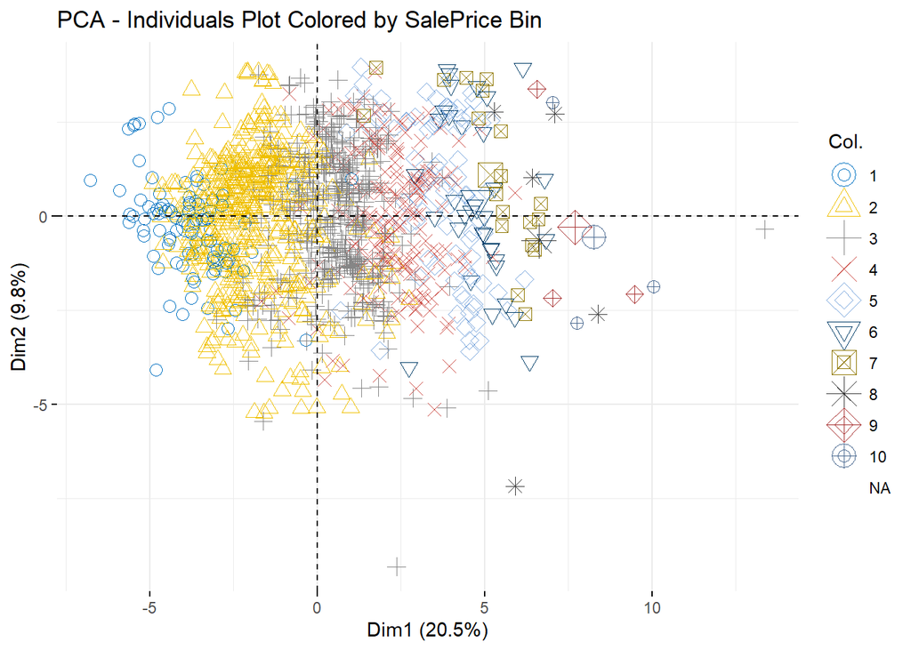

```r
# Perform PCA using prcomp()
pca_model <- prcomp(hp_num, center = TRUE, scale. = TRUE)



# Plot PCA scatterplot by SalePrice bin
fviz_pca_ind(pca_model, geom = "point", pointsize = 3,
             col.ind = hp$SalePrice_Bin,
             palette = "jco", repel = TRUE,
             title = "PCA - Individuals Plot Colored by SalePrice Bin")
```

## PCA biplot with Observations filtered by SalePrice Bin.

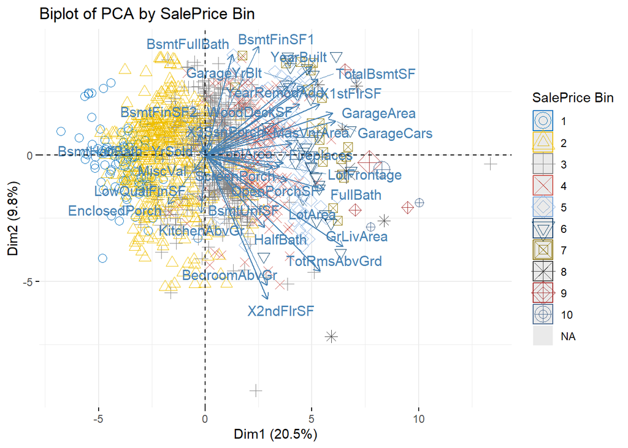

```r
# Create a PCA biplot with observations filtered by SalePrice bin
fviz_pca_biplot(pca_model,
                geom.ind = "point",         # Use points for individuals
                col.ind = hp$SalePrice_Bin, # Color by SalePrice bin
                palette = "jco",            # Use a nice color palette
                pointsize = 3,              # Adjust point size
                addEllipses = TRUE,         # making clusters clear for each bin
                repel = TRUE,               # Avoid label overlap
                legend.title = "SalePrice Bin",
                title = "Biplot of PCA by SalePrice Bin")
```

```r
# Top 10 Features
```

## Top 10 Features of PCA Biplot

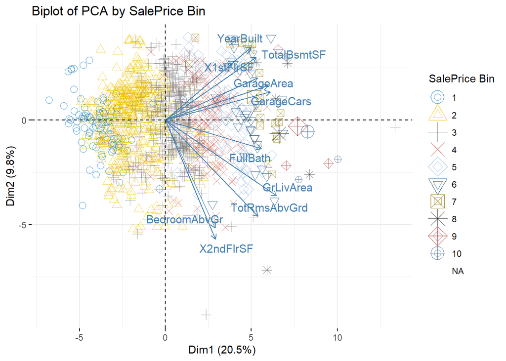

```r
fviz_pca_biplot(pca_model,
                geom.ind = "point",         # Use points for individuals
                col.ind = hp$SalePrice_Bin, # Color by SalePrice bin
                palette = "jco",            # Use a nice color palette
                pointsize = 3,              # Adjust point size
                repel = TRUE,               # Avoid label overlap
                alpha.ind = 0.7,   #Adds slight transparency to the points
                select.var = list(contrib = 10), # Show only the top 10 contributing features
                legend.title = "SalePrice Bin",
                title = "Biplot of PCA by SalePrice Bin")
```

The plots above display the relative position of each data point based on the first 2 dimensions: PC1 explains 20.5% variance and PC2 explains 9.8% variance, capturing 30% variability in the dataset. The plots help identify clusters and patterns in data. Most of the houses, especially in the lower sale price bins (2,3,4) are clustered near the center, representing bulk of data i.e, Most houses have low sale price. Houses in price bins 7 to 10 are more spread out towards the right side of the plot, indicating more variability, high price, and having other features.

The top features used the most in the the components and capturing most of the variance in the data are BedroomAbvGr, GarageArea, YearBuilt, TotalBsmtSF, GrLivArea, TotRmsAbvGrd and others, indicating these factors may be associated the most with the sale price.

# Clustering on Raw Data

## K-Means Clustering

Performing K-Means clustering on the raw dataset and evaluate using Silhouette Score and Elbow Method.

```r
scaled_data <- hp_num

# Convert list to data frame
scaled_data <- as.data.frame(scaled_data)

# Checking for missing or infinite values in the dataset
any(is.na(scaled_data))     # Returns TRUE if there are any NAs
```

```
## [1] FALSE
```

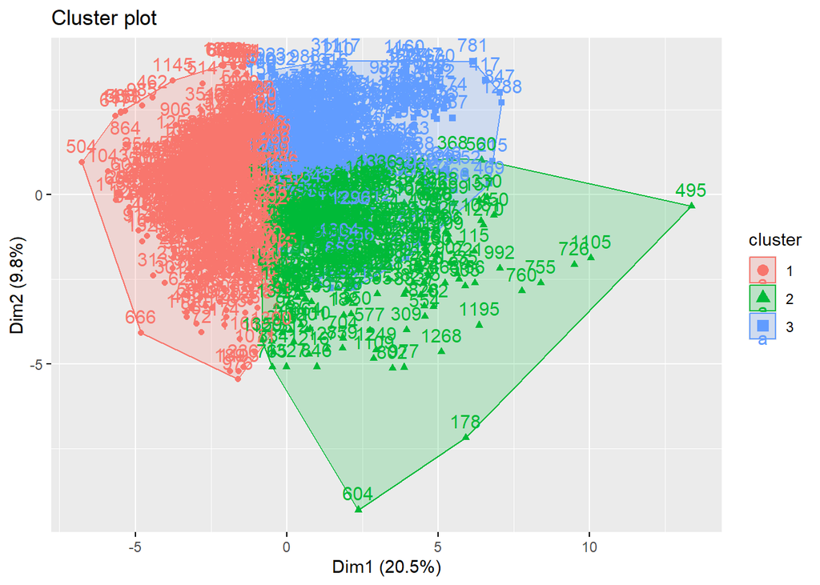

```r
# Removing rows with NA values
scaled_data <- na.omit(scaled_data)  # Removes rows with NA values

# Perform K-Means Clustering
kmeans_model <- kmeans(scaled_data, centers = 3, nstart = 25)

# Visualize Clusters
fviz_cluster(kmeans_model, data = scaled_data)
```

[figure not shown]

```r
# Silhouette Score
silhouette_score <- silhouette(kmeans_model$cluster, dist(scaled_data))
plot(silhouette_score, col = 2:4)
```

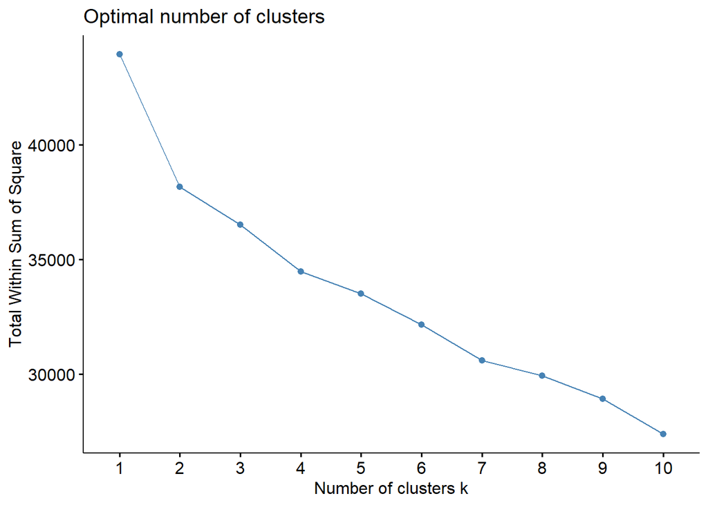

```r
# Elbow Method
fviz_nbclust(scaled_data, kmeans, method = "wss")
```

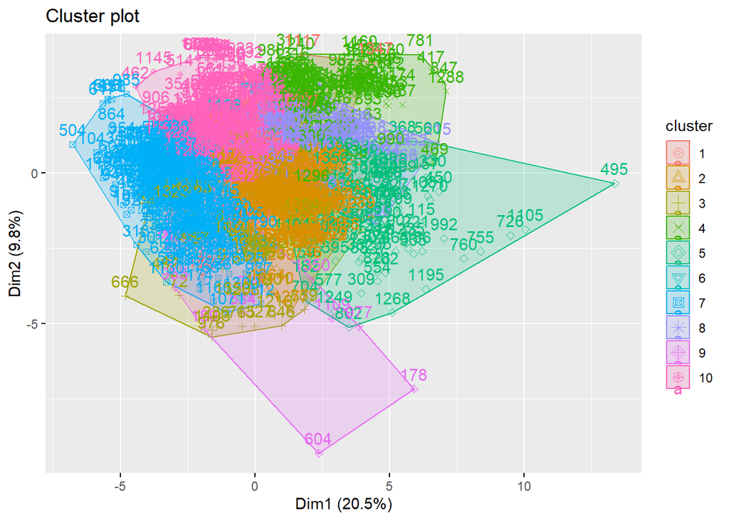

```r
# Perform K-Means Clustering
kmeans_model <- kmeans(scaled_data, centers = 10, nstart = 25)

# Visualize Clusters
fviz_cluster(kmeans_model, data = scaled_data)
```

[figure not shown]

```r
# Silhouette Score
silhouette_score <- silhouette(kmeans_model$cluster, dist(scaled_data))
plot(silhouette_score, col = 2:4)
```

K-Means clustering is performed on the dataset with the assumption that there are 3 clusters (centers = 3). The nstart = 25 argument ensures that the algorithm runs 25 times with different initial centroids to minimize the risk of getting stuck in local optima. From the visualization of K-Means clustering on the raw data it can be seen that the three clusters are not distinct and have overlapping.

## Hierarchical Clustering

Performing Agglomerative clustering using Complete-Link.

```r
scaled_data_hc <- hp

# Convert list to data frame
scaled_data_hc <- as.data.frame(scaled_data)

# Checking for missing or infinite values in the dataset
any(is.na(scaled_data_hc))     # Returns TRUE if there are any NAs
```

```
## [1] FALSE
```

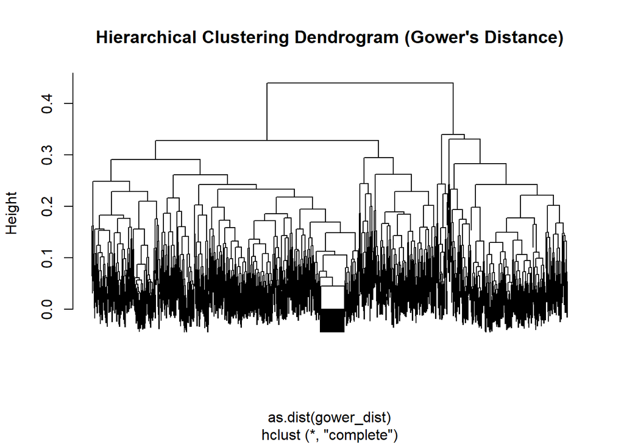

```r
# Removing rows with NA values
scaled_data_hc <- na.omit(scaled_data_hc)  # Removes rows with NA values

# Compute Gower's Distance
# Gower's distance handles both numeric and categorical variables
gower_dist <- daisy(scaled_data_hc, metric = "gower")

# Perform Hierarchical Clustering using Complete-Link
hc_model <- hclust(as.dist(gower_dist), method = "complete")

# Plot Dendrogram
plot(hc_model, labels = FALSE, main = "Hierarchical Clustering Dendrogram (Gower's Distance)")
```

```r
# Calculate Cophenetic Correlation Coefficient
cophenetic_correlation <- cor(cophenetic(hc_model), as.dist(gower_dist))
print(paste("Cophenetic Correlation Coefficient:", round(cophenetic_correlation, 4)))
```

```
## [1] "Cophenetic Correlation Coefficient: 0.4761"
```

Hierarchical clustering is performed using the hclust() function with the “complete” linkage method. This method merges clusters based on the maximum pairwise distance between points in two different clusters. The as.dist() function converts the Gower’s distance matrix into a distance object suitable for clustering. The choice of “complete” linkage means that the clustering algorithm will prioritize keeping clusters compact, as it merges the closest clusters based on the furthest points between them. This approach can be useful for ensuring that clusters remain well-separated.

# Clustering on PCA-Transformed Data

## K-Means Clustering

Repeating the clustering methods on the PCA-transformed dataset (using first N components that explain 90% of variance).

```r
pca_data <- pca_model$x[, 1:which(cumulative_variance >= 0.9)[1]]

# Convert list to data frame
pca_data <- as.data.frame(pca_data)

# Checking for missing or infinite values in the dataset
any(is.na(pca_data))     # Returns TRUE if there are any NAs
```

```
## [1] FALSE
```

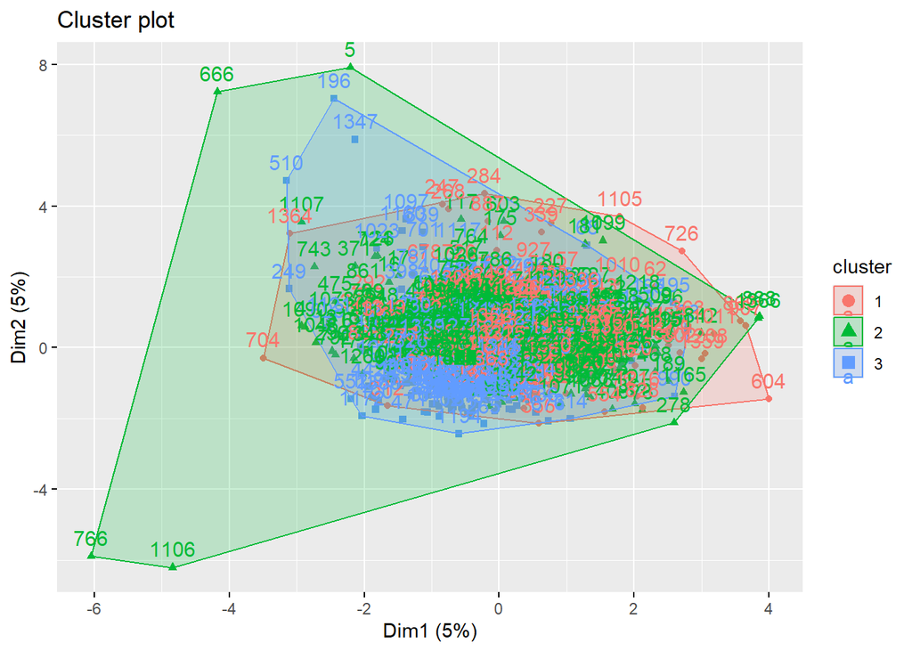

```r
# Removing rows with NA values
pca_data <- na.omit(pca_data)  # Removes rows with NA values

# Perform K-Means Clustering
kmeans_model_pca <- kmeans(pca_data, centers = 3, nstart = 25)

# Visualize Clusters
fviz_cluster(kmeans_model_pca, data = pca_data)
```

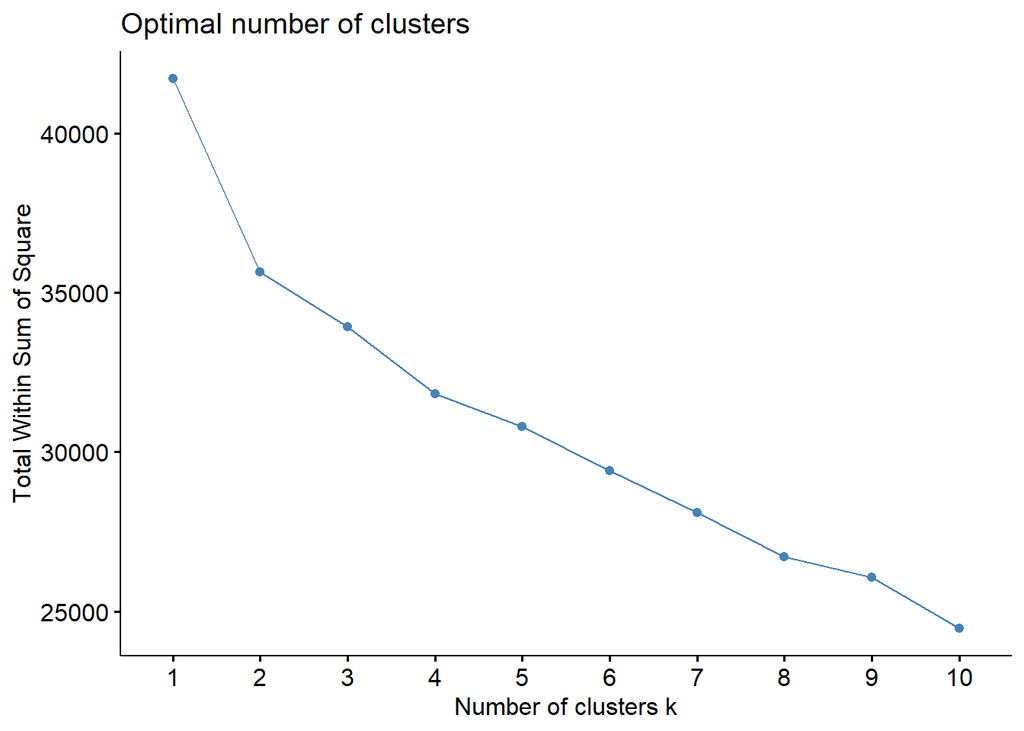

```r
# Elbow Method
fviz_nbclust(pca_data, kmeans, method = "wss")
```

## Hierarchical Clustering

Performing Agglomerative clustering using Complete-Link on PCA Data.

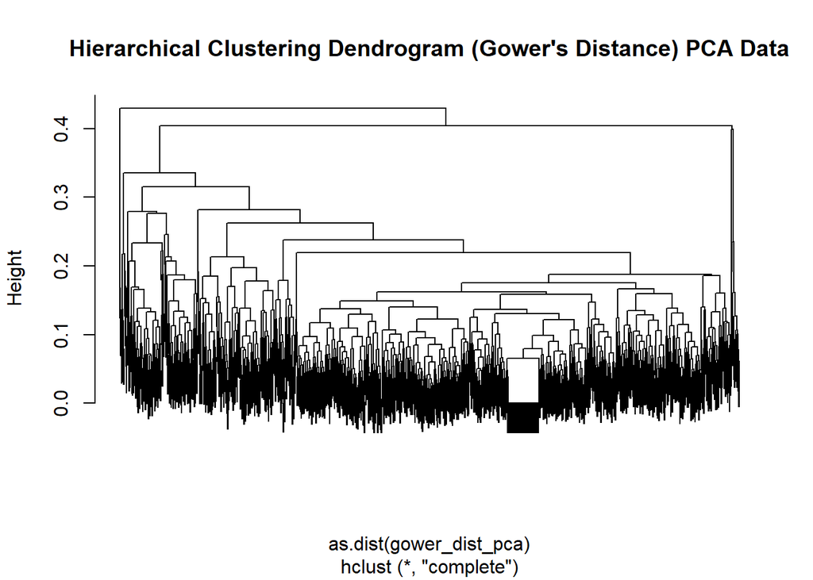

```r
# Compute Gower's Distance
# Gower's distance handles both numeric and categorical variables
gower_dist_pca <- daisy(pca_data, metric = "gower")

# Perform Hierarchical Clustering using Complete-Link
hc_model_pca <- hclust(as.dist(gower_dist_pca), method = "complete")

# Plot Dendrogram
plot(hc_model_pca, labels = FALSE, main = "Hierarchical Clustering Dendrogram (Gower's Distance) PCA Data")
```

```r
# Calculate Cophenetic Correlation Coefficient
cophenetic_correlation_pca <- cor(cophenetic(hc_model_pca), as.dist(gower_dist_pca))
print(paste("Cophenetic Correlation Coefficient:", round(cophenetic_correlation_pca, 4)))
```

```
## [1] "Cophenetic Correlation Coefficient: 0.5834"
```

# Comparison and Interpretation of Clustering using Raw Data and PCA Data

Compare the clustering results (raw vs. PCA) and assess performance using Silhouette Scores.

[figure not shown]

```r
# Silhouette Score for PCA-based clustering
silhouette_pca <- silhouette(kmeans_model_pca$cluster, dist(pca_data))
plot(silhouette_pca, col = 2:4, main = "Silhouette Plot for PCA-Based Clustering")
```

Test clustering stability by varying cluster numbers.

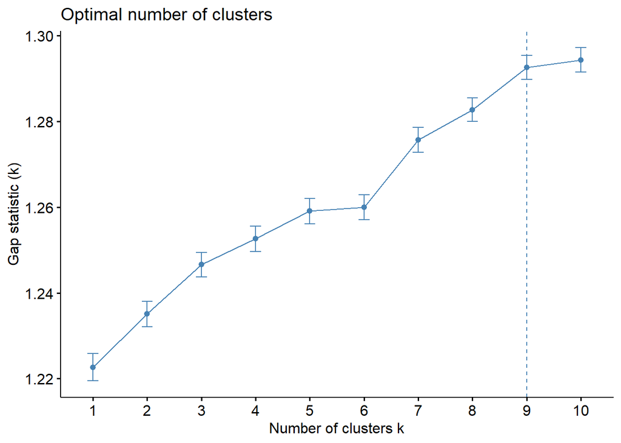

```r
# Filter only numeric columns
numeric_data <- scaled_data[sapply(scaled_data, is.numeric)]

# Scale the numeric data
numeric_data <- scale(numeric_data)

# Calculate Gap Statistic
gap_stat <- clusGap(numeric_data, FUN = function(x, k) kmeans(x, centers = k, nstart = 25, iter.max = 100), K.max = 10, B = 50)

# Visualize Gap Statistic
library(factoextra)
fviz_gap_stat(gap_stat)
```

It can be seen from the above graph that the Optimal Number of Clusters after many iterations also comes out to have the same same distribution from one to ten as seen in the above two graphs when we were using K-Means using raw data and PCA data as well. This is a good robustness check to make sure the K-Means is converging at the right point.

# Clustering and Prediction with Binned SalePrice

In this section we will be utilizing the Gaussian Mixture Model (GMM) to predict which bin or cluster a specifc point belongs to. We intially binned the SalePrice variable into 10 bins with scale of 1 to 10, with 1 showing very low prices and 10 showing very high house prices.

## Fit Gaussian Mixture Model (GMM)

```r
library(mclust)

# Convert list to data frame
hp <- as.data.frame(hp)

# Checking for missing or infinite values in the dataset
any(is.na(hp))     # Returns TRUE if there are any NAs
```

```
## [1] TRUE
```

```r
# Removing rows with NA values
hp <- na.omit(hp)  # Removes rows with NA values

# Fit GMM model with 10 components
gmm_model <- Mclust(data = select(hp, -SalePrice_Bin), G = 10)

# View model summary
summary(gmm_model)
```

```
## ----------------------------------------------------
## Gaussian finite mixture model fitted by EM algorithm
## ----------------------------------------------------
##
## Mclust VII (spherical, varying volume) model with 10 components:
##
##  log-likelihood    n  df     BIC       ICL
##       -154316.6 1288 819 -314498 -314526.1
##
## Clustering table:
##   1   2   3   4   5   6   7   8   9  10
## 105 221 230  91 187  69 108  87 186   4
```

```r
# Predicted clusters for train data
hp$Predicted_Bin <- as.factor(gmm_model$classification)
```

This code fits a Gaussian Mixture Model (GMM) to the dataset using the mclust package. The dataset hp is first cleaned by removing rows with missing values. Then, the GMM is applied with 10 components (G = 10) to identify distinct clusters in the data (excluding the target variable SalePrice_Bin). The predicted cluster assignments are stored in the Predicted_Bin column for further analysis.

GMM is a probabilistic model that assumes the data comes from a mixture of several Gaussian distributions. Fitting the GMM allows us to identify underlying subgroups in the dataset based on the continuous features. The summary of the GMM model will provide information on the number of components, model fit, and the covariance structure of each component. The predicted cluster assignments (Predicted_Bin) will help classify each observation into one of the identified clusters.

## Validate Clustering on Train Data

```r
# Create a confusion matrix
confusion_matrix <- table(Actual = hp$SalePrice_Bin, Predicted = hp$Predicted_Bin)
print(confusion_matrix)
```

```
##       Predicted
## Actual   1   2   3   4   5   6   7   8   9  10
##     1    0  16   5   0  19   0   0  11   7   0
##     2    0 152  82   0 100   4   0  43  79   4
##     3   67  49  85  18  39  36  26  28  74   0
##     4   32   4  28  34  24  23  33   3  13   0
##     5    4   0  17  20   3   5  26   1  10   0
##     6    1   0   6   8   2   1  15   0   1   0
##     7    1   0   4   7   0   0   6   1   0   0
##     8    0   0   1   2   0   0   1   0   1   0
##     9    0   0   1   1   0   0   0   0   1   0
##     10   0   0   1   1   0   0   1   0   0   0
```

```r
# Calculate accuracy
accuracy <- sum(diag(confusion_matrix)) / sum(confusion_matrix)
print(paste("Clustering Accuracy:", round(accuracy, 4)))
```

```
## [1] "Clustering Accuracy: 0.2189"
```

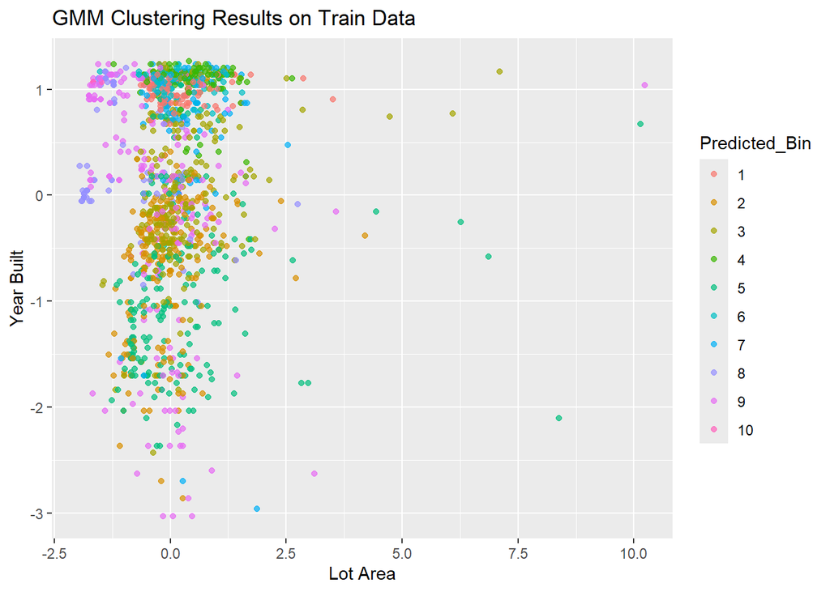

```r
# Visualize clusters
library(ggplot2)
ggplot(hp, aes(x = LotArea, y = YearBuilt, color = Predicted_Bin)) +
  geom_point(alpha = 0.7) +
  labs(title = "GMM Clustering Results on Train Data",
       x = "Lot Area",
       y = "Year Built")
```

This code validates the performance of the GMM clustering by comparing the predicted clusters (Predicted_Bin) against the actual SalePrice_Bin values. A confusion matrix is created to show how well the predicted cluster assignments match the actual categories. Additionally, a scatter plot is created to visualize the clustering results in terms of two variables, LotArea and YearBuilt, with different clusters represented by different colors. Interpretation: The confusion matrix helps assess how well the GMM model has classified the data into clusters that correspond to the actual target variable (SalePrice_Bin).

The Accuracy we got from this exercise is pretty low and comes out to be approximately 22%. This low accuracy can be due to the following reasons:

Clustering algorithms like GMM are unsupervised and do not use the actual target variable (SalePrice_Bin) during the fitting process. Therefore, the clusters identified by GMM may not perfectly align with the actual labels, which can result in low accuracy.

GMM tries to find natural groupings in the data, but these may not correspond to the binarized SalePrice_Bin values, especially if the relationship between the features and the target variable is not linear or not easily separable by Gaussian distributions.

# Code for better interpretability

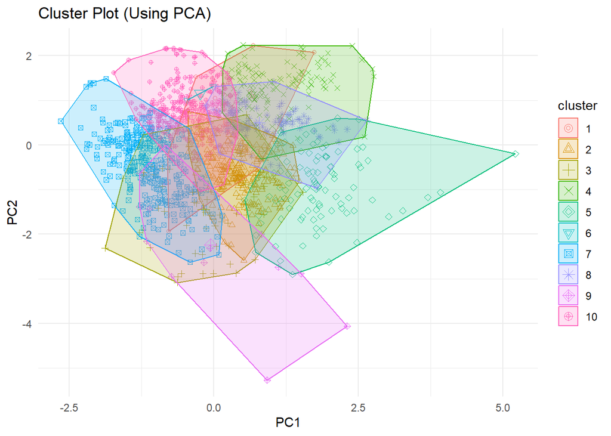

```r
scaled_data <- scale(scaled_data)

library(factoextra)
library(ggplot2)

# Perform PCA on the scaled dataset
pca_result <- prcomp(scaled_data, center = TRUE, scale. = TRUE)

# Visualize clusters using PCA
fviz_cluster(kmeans_model, geom = "point", data = pca_result$x[, 1:2]) +
  labs(title = "Cluster Plot (Using PCA)", x = "PC1", y = "PC2") +
  theme_minimal()
```

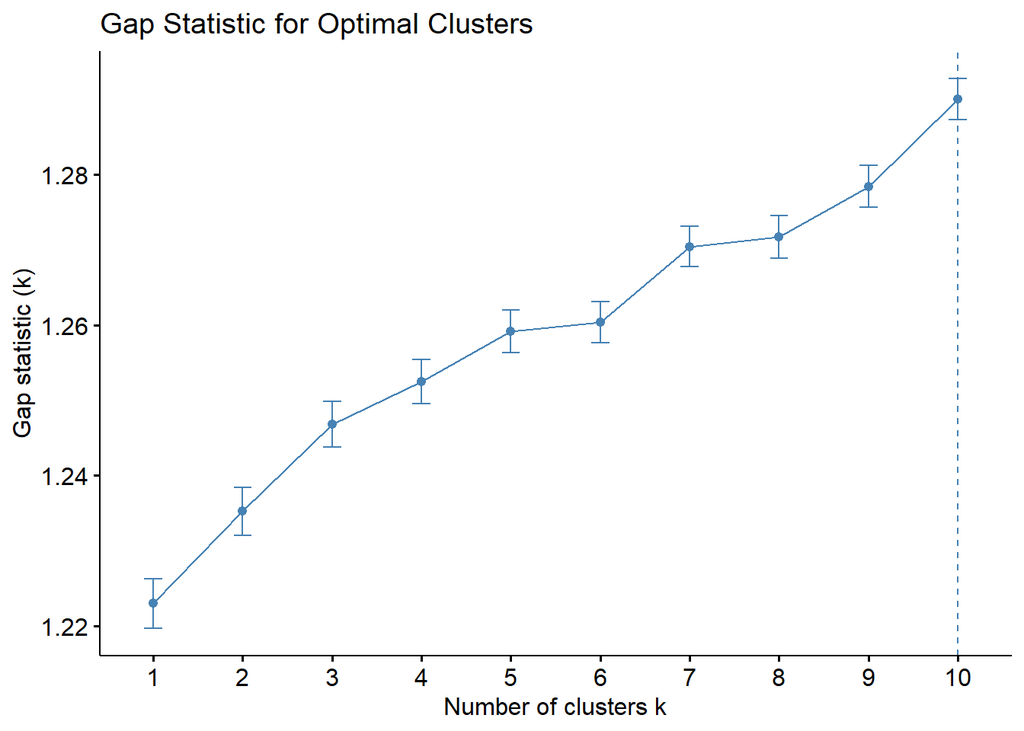

```r
library(cluster)

# Compute gap statistic to find the optimal number of clusters
gap_stat <- clusGap(scaled_data, FUN = function(x, k) kmeans(x, centers = k, nstart = 25, iter.max = 100), K.max = 10, B = 50)
fviz_gap_stat(gap_stat) +
  labs(title = "Gap Statistic for Optimal Clusters")
```

[output not shown]

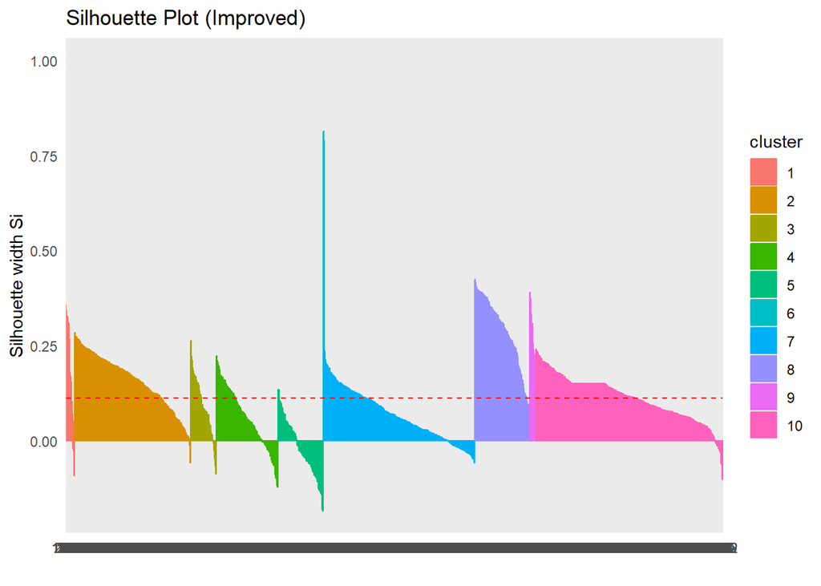

```r
# Recompute silhouette scores with the optimal clusters
silhouette_score <- silhouette(kmeans_model$cluster, dist(scaled_data))

# Visualize silhouette scores
fviz_silhouette(silhouette_score) +
  labs(title = "Silhouette Plot (Improved)") +
  theme_minimal()
```

```r
# Add cluster assignments to the original data
scaled_data$Cluster <- as.factor(kmeans_model$cluster)

# Ensure scaled_data is a data frame with proper column names
scaled_data <- as.data.frame(scaled_data)
colnames(scaled_data) <- paste0("Var", 1:ncol(scaled_data))  # Replace with real variable names if available
scaled_data$Cluster <- as.factor(kmeans_model$cluster)  # Add the cluster assignments

# Summarize cluster characteristics
cluster_summary <- aggregate(. ~ Cluster, data = scaled_data, mean)
print(cluster_summary[,1:10])
```

```
##    Cluster       Var1      Var2        Var3       Var4      Var5      Var6
## 1        1 -0.2253728 0.5383121 -0.07263586 -0.4799345 0.7928737 0.2837504
## 2        2 -0.2253728 0.5383121 -0.07263586 -0.4799345 0.7928737 0.2837504
## 3        3 -0.2253728 0.5383121 -0.07263586 -0.4799345 0.7928737 0.2837504
## 4        4 -0.2253728 0.5383121 -0.07263586 -0.4799345 0.7928737 0.2837504
## 5        5 -0.2253728 0.5383121 -0.07263586 -0.4799345 0.7928737 0.2837504
## 6        6 -0.2253728 0.5383121 -0.07263586 -0.4799345 0.7928737 0.2837504
## 7        7 -0.2253728 0.5383121 -0.07263586 -0.4799345 0.7928737 0.2837504
## 8        8 -0.2253728 0.5383121 -0.07263586 -0.4799345 0.7928737 0.2837504
## 9        9 -0.2253728 0.5383121 -0.07263586 -0.4799345 0.7928737 0.2837504
## 10      10 -0.2253728 0.5383121 -0.07263586 -0.4799345 0.7928737 0.2837504
##           Var7       Var8       Var9
## 1  -0.02172354 -0.9381454 -0.9890578
## 2  -0.02172354 -0.9381454 -0.9890578
## 3  -0.02172354 -0.9381454 -0.9890578
## 4  -0.02172354 -0.9381454 -0.9890578
## 5  -0.02172354 -0.9381454 -0.9890578
## 6  -0.02172354 -0.9381454 -0.9890578
## 7  -0.02172354 -0.9381454 -0.9890578
## 8  -0.02172354 -0.9381454 -0.9890578
## 9  -0.02172354 -0.9381454 -0.9890578
## 10 -0.02172354 -0.9381454 -0.9890578
```